# Arsenic Genotype Comparison

DMG

8/16/2022

# Arsenic Project Genotype Comparison

There are roughly 570 mice listed in the arsenic project. I don’t currently have an exhaustive list of mouse IDs with sex, dose, generation and a cross-reference between mouse, cell lines, Neogen DNA, and bulk RNA-seq.

I want to make sure that the genotypes from the Gigamuga match the EMASE/GBRS genotypes in the RNA-seq data.

## Genotype Files

There are three separate Gigamuga files:

1. Jackson_Lab_Korstanje__GigaMUGA_genoprobs_8state_69k_sorted.rds: The first batch Gigamuga file using DNA from the spleens of mice.
2. 43_DO_Korstanje_Redo__GigaMUGA_genoprobs_8state_69k.rds: A set of 43 samples which were re-run because they failed QC in the first batch.
3. cell_gig_data__GigaMUGA_genoprobs_8state_69k.rds: Cell lines run to try to fill in mouse samples that failed QC in both of the first two batches.

There is one GBRS file:

1. arsenic_gbrs_alleleprobs.rds: Allele probabilities for 282 samples.

## Annotation Files

Arsenic Extracted DNA.xlsx: 571 rows, 4 columns. Each row represents one mouse. Column names: Extracted DNA: ID for extracted DNA sent to Neogen. Spleen Sample: ID for spleen samples. Animal: Mouse ID. Wave: Wave of the experiment.

muga_to_id.csv: 626 rows, 5 columns. Column names: Project: Experiment project name.  
Investigator: Principal investigator name. Directory: Directory name of Gigamuga file. id: Extracted DNA ID. Unique.Sample.ID:

ArsenicAnimalMetadata.csv: 565 rows, 5 columns. Column Names: Name: Mouse ID Sex: Sex of mouse (Female or Male) Generation: DO outbreeding generation (G34 - G37). Diet: Diet with dose of As. Birth Date: Birth date.

I am trying to re-generate genoprobs using the Study Intake Platform. It’s still processing right now. I have genotypes extracted from the EMASE output and genoprobs from GBRS on the 69K grid. I’d like to do this to verify that no mixups occurred during genotype processing.

## Load Data

Read in the Gigamuga marker grid.

```r
markers = read_csv(marker_file) %>%
            filter(chr %in% c(1:19, 'X')) %>%
            mutate(bp_mm10 = bp_mm10 * 1e-6) %>%
            as.data.frame()
```

```r
marker_map = qtl2convert::map_df_to_list(markers, pos_column = 'bp_mm10')

grid69k = read_delim(grid69k_file, delim = '\t') %>%
            as.data.frame()
grid69k_map = qtl2convert::map_df_to_list(grid69k, pos_column = 'pos')
```

Read in GBRS genoprobs. These are in DOQTL format on the 69K grid.

```r
gbrs = readRDS(gbrs_geno_file)
gbrs = qtl2convert::probs_doqtl_to_qtl2(gbrs, map = grid69k, pos_column = 'pos')
gc()
```

```
##             used   (Mb) gc trigger   (Mb)  max used   (Mb)
## Ncells   1689483   90.3    3137447  167.6   2504828  133.8
## Vcells 162018466 1236.2  456637426 3483.9 473934925 3615.9
```

Read in Gigamuga genoprobs. These are on the 69K grid, but are in DOQTL format.

```r
giga = readRDS(gigamuga_geno_file)
giga = qtl2convert::probs_doqtl_to_qtl2(giga, map = grid69k, pos_column = 'pos')
```

Read in the second batch of Gigamuga data. These are on the 69K grid, but are in DOQTL format.

```r
giga2 = readRDS(gigamuga_redo_file)
giga2 = qtl2convert::probs_doqtl_to_qtl2(giga2, map = grid69k, pos_column = 'pos')
```

## Verify Markers Identical

Verify that the markers in both files have the same markers. We’re using the 69K grid.

```r
all(sapply(gbrs, dim)[3,] == sapply(giga,  dim)[3,])
```

```
## [1] TRUE
```

```r
all(sapply(gbrs, dim)[3,] == sapply(giga2, dim)[3,])
```

```
## [1] TRUE
```

## Verify Sample Identity

Verify that the sample IDs in the GBRS data are a subset of the sample IDs in the Gigamuga data.

```r
all(rownames(gbrs[[1]]) %in% rownames(giga[[1]]))
```

```
## [1] FALSE
```

The sample IDs are different. What proportion of GBRS samples don’t match the Gigamuga samples?

```r
mean(rownames(gbrs[[1]]) %in% rownames(giga[[1]]))
```

```
## [1] 0
```

No samples match between the Gigamuga and GBRS data.

Check the sample matching between the redo and GBRS samples.

```r
all(rownames(gbrs[[1]]) %in% rownames(giga2[[1]]))
```

```
## [1] FALSE
```

### Read Sample Annotation

I’ll use the annotation files listed at the beginning of the document to assign mouse IDs to each sample.

```r
metadata   = read_csv(metadata_file)
mouse_giga = read_xlsx(mouse_giga_file)
mouse_rna  = read_csv(rnaseq_file, col_names = FALSE)
colnames(mouse_rna) = c('dose', 'sex', 'mouse', 'fastq1', 'tissue', 'gen', 'fastq2')
```

Which IDs are used in the first batch of Gigamuga data?

```r
# Remove prefix from Sample IDs.
for(i in seq_along(giga)) {
  rownames(giga[[i]]) = gsub('^Jackson_Lab_Korstanje_MURGIGV01_[0-9]+_|_[A-H][0-9]+', '', rownames(giga[[i]]))
} # for(i)

mean(rownames(giga[[1]]) %in% mouse_giga$`Extracted DNA`)
```

```
## [1] 0.9103053
```

Most of the samples in the Gigamuga data are in the Gigamuga sample file. The Gigamuga data has been filtered, so this may be OK.

Which IDs are used in the second batch of Gigamuga data?

```r
# Remove prefix from Sample IDs.
for(i in seq_along(giga2)) {
  rownames(giga2[[i]]) = gsub('^Jackson_Lab_Korstanje_MURGIGV01_[0-9]+_|_[A-H][0-9]+', '', rownames(giga2[[i]]))
} # for(i)

mean(rownames(giga2[[1]]) %in% mouse_giga$`Extracted DNA`)
```

```
## [1] 0.9767442
```

Which IDs are used in the GBRS data?

```r
mouse_rna$id = gsub('_GT22-[0-9]+_[ACGT]+-[ACGT]+_S[0-9]+_L[0-9]+_R[0-9]_[0-9]+\\.fastq\\.gz$', '', mouse_rna$fastq1)
mean(rownames(gbrs[[1]]) %in% mouse_rna$id)
```

```
## [1] 1
```

All of the kidney RNA-seq samples are in the annotation file. I’m not sure about the phase I samples, which were from heart, liver, and kidney in the 0 and 10 ppm dose groups.

### Assign Mouse IDs

Assign mouse IDs to first batch Gigamuga data.

```r
m = match(rownames(giga[[1]]), mouse_giga$`Extracted DNA`)

giga_match = cbind(rownames(giga[[1]]), mouse_giga$`Extracted DNA`[m], mouse_giga$Animal[m])

for(i in seq_along(giga)) {
  rownames(giga[[i]])[!is.na(m)] = mouse_giga$Animal[m[!is.na(m)]]
} # for(i)
```

Print out the table of first batch Gigamuga sample to Mouse ID.

```r
giga_match
```

```
##        [,1]         [,2]        [,3]
##   [1,] "X-2148-20"  "X-2148-20" "A-10049-19"
##   [2,] "X-2159-20"  "X-2159-20" "A-10060-19"
##   [3,] "B6 - 1614A" NA          NA
##   [4,] "X-2184-20"  "X-2184-20" "A-10093-19"
##   [5,] "X-2196-20"  "X-2196-20" "A-10108-19"
##   [6,] "X-2210-20"  "X-2210-20" "A-10126-19"
##   [7,] "X-5158-20"  "X-5158-20" "A-10140-19"
##   [8,] "B6 - 1614"  NA          NA
##   [9,] "X-2149-20"  "X-2149-20" "A-10050-19"
##  [10,] "X-2160-20"  "X-2160-20" "A-10061-19"
##  [11,] "X-2172-20"  "X-2172-20" "A-10077-19"
##  [12,] "X-2185-20"  "X-2185-20" "A-10094-19"
##  [13,] "X-2197-20"  "X-2197-20" "A-10110-19"
##  [14,] "X-2211-20"  "X-2211-20" "A-10127-19"
```

[output cut: 510 more lines]

Assign mouse IDs to second batch Gigamuga data.

```r
m = match(rownames(giga2[[1]]), mouse_giga$`Extracted DNA`)

giga2_match = cbind(rownames(giga2[[1]]), mouse_giga$`Extracted DNA`[m], mouse_giga$Animal[m])

for(i in seq_along(giga2)) {
  rownames(giga2[[i]])[!is.na(m)] = mouse_giga$Animal[m[!is.na(m)]]
} # for(i)
```

Print out the table of second batch Gigamuga sample to Mouse ID.

```r
giga2_match
```

```
##       [,1]        [,2]        [,3]
##  [1,] "X-5187-20" "X-5187-20" "A-10178-19"
##  [2,] "X-5467-20" "X-5467-20" "A-10356-19"
##  [3,] "X-8542-20" "X-8542-20" "A-10617-19"
##  [4,] "X-8638-20" "X-8638-20" "A-100038-20"
##  [5,] "X-5190-20" "X-5190-20" "A-10182-19"
##  [6,] "X-5490-20" "X-5490-20" "A-10351-19"
##  [7,] "X-8544-20" "X-8544-20" "A-10619-19"
##  [8,] "X-5195-20" "X-5195-20" "A-10188-19"
##  [9,] "X-5499-20" "X-5499-20" "A-10368-19"
## [10,] "X-8560-20" "X-8560-20" "A-10635-19"
## [11,] "X-5198-20" "X-5198-20" "A-10191-19"
## [12,] "X-5507-20" "X-5507-20" "A-10376-19"
## [13,] "X-8572-20" "X-8572-20" "A-10648-19"
## [14,] "X-5232-20" "X-5232-20" "A-10237-19"
```

[output cut: 29 more lines]

Assign mouse IDs to GBRS data.

```r
m = match(rownames(gbrs[[1]]), mouse_rna$id)

gbrs_match = cbind(rownames(gbrs[[1]]), mouse_rna$id[m], mouse_rna$mouse[m])

for(i in seq_along(gbrs)) {
   rownames(gbrs[[i]]) = mouse_rna$mouse[m]
} # for(i)
```

```r
gbrs_match
```

```
##        [,1]         [,2]         [,3]
##   [1,] "X-10719-21" "X-10719-21" "A-100023-20"
##   [2,] "X-10720-21" "X-10720-21" "A-100024-20"
##   [3,] "X-10837-21" "X-10837-21" "A-100055-20"
##   [4,] "X-10812-21" "X-10812-21" "A-100027-20"
##   [5,] "X-10810-21" "X-10810-21" "A-100025-20"
##   [6,] "X-8922-21"  "X-8922-21"  "A-10061-19"
##   [7,] "X-8920-21"  "X-8920-21"  "A-10059-19"
##   [8,] "X-10835-21" "X-10835-21" "A-100053-20"
##   [9,] "X-8916-21"  "X-8916-21"  "A-10055-19"
##  [10,] "X-10836-21" "X-10836-21" "A-100054-20"
##  [11,] "X-8918-21"  "X-8918-21"  "A-10057-19"
##  [12,] "X-10811-21" "X-10811-21" "A-100026-20"
##  [13,] "X-8912-21"  "X-8912-21"  "A-10051-19"
##  [14,] "X-8915-21"  "X-8915-21"  "A-10054-19"
```

[output cut: 268 more lines]

## Genoprobs Comparison

Retain the intersection of the samples in the Gigamuga and GBRS data.

```r
samples = intersect(c(rownames(giga[[1]]), rownames(giga2[[1]])), rownames(gbrs[[1]]))
length(samples)
```

```
## [1] 165
```

There are only 165 samples that are common between the two datasets. The RNA-seq data has 282 samples, so there are a lot missing. Use the intersection for now, but I’ll need to find the other samples.

```r
for(i in seq_along(giga)) {
  giga[[i]]  = giga[[i]][rownames(giga[[i]])   %in% samples,,]
  giga2[[i]] = giga2[[i]][rownames(giga2[[i]]) %in% samples,,]
  gbrs[[i]]  = gbrs[[i]][samples,,]
} # for(i)
```

Combine the two Gigamuga data sets.

```r
new_giga = vector('list', length = length(giga))
names(new_giga) = names(giga)

for(i in seq_along(giga)) {

  comb_samples = c(rownames(giga[[i]]), rownames(giga2[[i]]))
  new_giga[[i]] = array(0, dim = c(length(comb_samples), ncol(giga[[i]]), dim(giga[[i]])[[3]]),
                        dimnames = list(comb_samples, colnames(giga[[i]]), dimnames(giga[[i]])[[3]]))
  new_giga[[i]][1:nrow(giga[[i]]),,] = giga[[i]]
  new_giga[[i]][(nrow(giga[[i]]) + 1):nrow(new_giga[[i]]),,] = giga2[[i]]

} # for(i)

rm(giga, giga2)
gc()
```

```
##             used   (Mb) gc trigger   (Mb)   max used   (Mb)
## Ncells   1699873   90.8    3137447  167.6    2999048  160.2
## Vcells 188629985 1439.2  869530462 6634.0 1085867903 8284.6
```

Reorder the samples to be identical in both the Gigamuga and GBRS data.

```r
for(i in seq_along(new_giga)) {
  new_giga[[i]] = new_giga[[i]][samples,,]
  gbrs[[i]]     = gbrs[[i]][samples,,]
} # for(i)
stopifnot(all(rownames(new_giga[[1]]) == rownames(gbrs[[1]])))
```

Convert both probs objects to 3D arrays to make the comparison easier.

```r
# NOTE: Couldn't get the qtl2convert function to work. It producced a lot of NAs.
#       Not sure if it's user error or bug.
chr_len = sapply(new_giga, dim)[3,]
mkr_names = unlist(sapply(new_giga, function(z) { dimnames(z)[[3]] }))
ng = array(0, dim = c(nrow(new_giga[[1]]), ncol(new_giga[[1]]), sum(chr_len)),
           dimnames = list(rownames(new_giga[[1]]), colnames(new_giga[[1]]), mkr_names))
gb = array(0, dim = c(nrow(gbrs[[1]]), ncol(gbrs[[1]]), sum(chr_len)),
           dimnames = list(rownames(gbrs[[1]]), colnames(gbrs[[1]]), mkr_names))

chr_len = c(0, cumsum(chr_len))

for(i in seq_along(new_giga)) {
  ng[,,(chr_len[i]+1):chr_len[i+1]] = new_giga[[i]]
  gb[,,(chr_len[i]+1):chr_len[i+1]] = gbrs[[i]]
  #print(paste(chr_len[i]+1, chr_len[i+1]))
} # for(i)

new_giga = ng
gbrs     = gb
rm(ng, gb)
```

Compare each sample.

```r
ng2 = sqrt(apply(new_giga^2, c(1,3), sum))
gb2 = sqrt(apply(gbrs^2,    c(1,3), sum))

num = apply(new_giga * gbrs, c(1, 3), sum)

sample_comp = num / (ng2 * gb2)
```

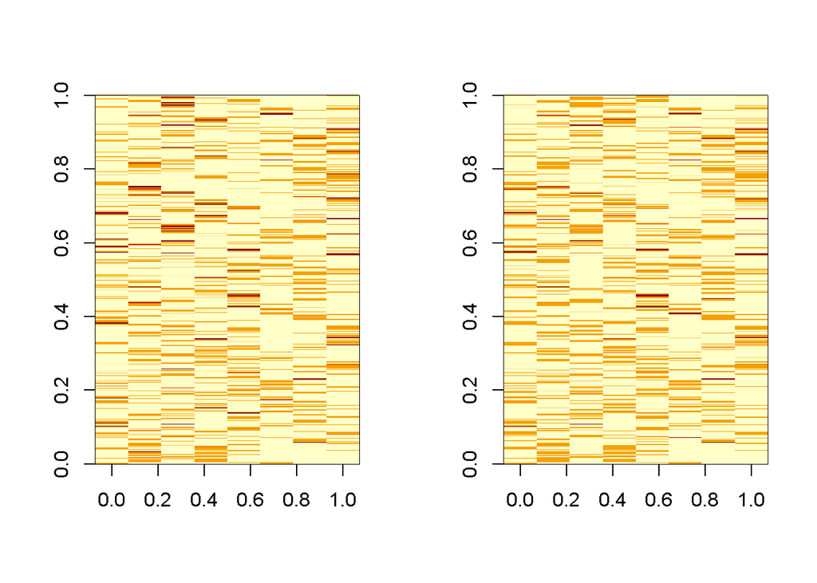

```r
par(mfrow = c(1, 2))
image(new_giga[1,,])
image(gbrs[1,,])
```